# znacajke

0036558540 Ivan Dražetić

2026-01-19

# Istraživačko pitanje: Možemo li pomoću dostupnih značajki pouzdano razlikovati pobjednike od ostalih?

#### U ovoj analizi istražujemo postoje li statistički značajne razlike između filmova koji su osvojili Oscara (“Winner”) i onih koji su bili samo nominirani (“Nominee”). Analizu provodimo na temelju dostupnih značajki: IMDb ocjene, žanra, godine izlaska i trajanja filma.

```r
oscars <- read.csv("oscars_dataset.csv", sep = ";", na.strings = c("", "NA", "Unknown"), encoding = "UTF-8")
```

#### Priprema podataka

Prije analize, uređujemo dataset: pretvaramo numeričke varijable u ispravan format, kreiramo binarnu varijablu za pobjedu te grupiramo rjeđe žanrove kako bismo osigurali stabilnost modela.

```r
# Pretvorbe tipova, uređivanje dataseta
oscars <- oscars %>%
  mutate(
    IMDB.Rating = as.numeric(IMDB.Rating),
    Year.of.Release = as.numeric(Year.of.Release),
    Movie.Time = as.numeric(Movie.Time),
    # Kreiranje binarne varijable (1 = Winner, 0 = Nominee)
    IsWinner = ifelse(Award == "Winner", 1, 0),
    # Grupiranje žanrova radi stabilnosti modela
    Main.Genre = ifelse(Main.Genre %in% c("Drama", "Comedy", "Biography", "Adventure", "Action", "Crime"),
                        Main.Genre, "Other"),
    Main.Genre = factor(Main.Genre),
    Award = factor(Award, levels = c("Nominee", "Winner"))
  ) %>%
  filter(complete.cases(IMDB.Rating, Main.Genre, Year.of.Release, Movie.Time, IsWinner))
```

Da bismo dobili uvid u razlike u ocjenama, vizualizirat ćemo distribucije ocjena za pobjednike i nominirane.

#### Box plot: Distribucija IMDb ocjena s obzirom na pobjedu

[figure not shown]

```r
ggplot(oscars, aes(x = Award, y = IMDB.Rating, fill = Award)) +
  geom_boxplot() +
  labs(
    x = "Ishod",
    y = "IMDb ocjena",
    title = "Distribucija IMDb ocjena s obzirom na pobjedu"
  )
```

#### Histogram: Pobjednici vs Nominirani

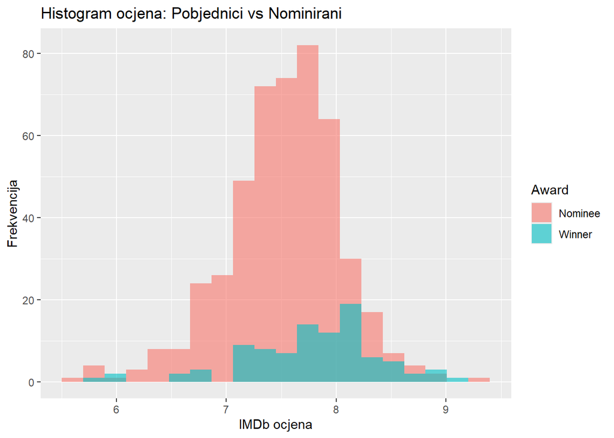

```r
ggplot(oscars, aes(x = IMDB.Rating, fill = Award)) +
  geom_histogram(position = "identity", alpha = 0.6, bins = 20) +
  labs(
    x = "IMDb ocjena",
    y = "Frekvencija",
    title = "Histogram ocjena: Pobjednici vs Nominirani"
  )
```

Također nas zanima imaju li određeni žanrovi veći udio pobjednika.

#### Stupčasti dijagram udjela pobjednika po žanru

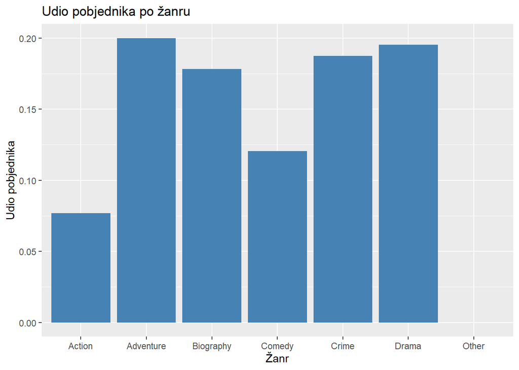

```r
genre_prop <- oscars %>%
  group_by(Main.Genre) %>%
  summarise(
    Total = n(),
    Winners = sum(IsWinner),
    PropWinner = Winners / Total
  )

ggplot(genre_prop, aes(x = Main.Genre, y = PropWinner)) +
  geom_col(fill = "steelblue") +
  labs(
    x = "Žanr",
    y = "Udio pobjednika",
    title = "Udio pobjednika po žanru"
  )
```

Kako bismo statistički provjerili postoji li razlika u IMDb ocjenama između pobjednika i ostalih, provest ćemo t-test.

#### t-test (IMDb ocjena: Pobjednici vs Ostali)

```r
t.test(IMDB.Rating ~ Award, data = oscars)
```

```
##
##  Welch Two Sample t-test
##
## data:  IMDB.Rating by Award
## t = -3.573, df = 120.07, p-value = 0.0005091
## alternative hypothesis: true difference in means between group Nominee and group Winner is not equal to 0
## 95 percent confidence interval:
##  -0.3895394 -0.1117541
## sample estimates:
## mean in group Nominee  mean in group Winner
##              7.529140              7.779787
```

Rezultati t-testa pokazuju statistički značajnu razliku u srednjim vrijednostima ocjena (p = 0.0005091 < 0.05). To znači da pobjednici u prosjeku imaju više ocjene od nominiranih.

Sada ćemo izgraditi prediktivni model koristeći logističku regresiju kako bismo procijenili vjerojatnost pobjede na temelju više značajki istovremeno.

#### Logistička regresija

```r
model <- glm(
  IsWinner ~ IMDB.Rating + Main.Genre + Year.of.Release + Movie.Time,
  data = oscars,
  family = binomial(link = "logit")
)

summary(model)
```

```
##
## Call:
## glm(formula = IsWinner ~ IMDB.Rating + Main.Genre + Year.of.Release +
##     Movie.Time, family = binomial(link = "logit"), data = oscars)
##
## Coefficients:
##                       Estimate Std. Error z value Pr(>|z|)
## (Intercept)           1.413908   8.774323   0.161  0.87198
## IMDB.Rating           0.734343   0.250839   2.928  0.00342 **
## Main.GenreAdventure   1.040600   0.746957   1.393  0.16358
## Main.GenreBiography   1.162477   0.680924   1.707  0.08778 .
## Main.GenreComedy      1.085377   0.708697   1.532  0.12564
## Main.GenreCrime       1.096404   0.739827   1.482  0.13835
## Main.GenreDrama       1.336590   0.654786   2.041  0.04122 *
## Main.GenreOther     -13.233791 595.590513  -0.022  0.98227
## Year.of.Release      -0.006177   0.004538  -1.361  0.17345
## Movie.Time            0.018617   0.004590   4.056 4.99e-05 ***
## ---
## Signif. codes:  0 '***' 0.001 '**' 0.01 '*' 0.05 '.' 0.1 ' ' 1
##
## (Dispersion parameter for binomial family taken to be 1)
##
##     Null deviance: 510.77  on 570  degrees of freedom
## Residual deviance: 464.92  on 561  degrees of freedom
## AIC: 484.92
##
## Number of Fisher Scoring iterations: 15
```

Za evaluaciju kvalitete modela, izračunat ćemo točnost (Accuracy), nacrtati ROC krivulju, izračunati površinu ispod krivulje (AUC) te McFaddenov pseudo-R².

#### Evaluacija modela: Accuracy

```r
predicted_probs <- predict(model, type = "response")
predicted_class <- ifelse(predicted_probs > 0.5, 1, 0)
accuracy <- mean(predicted_class == oscars$IsWinner)
print(paste("Accuracy:", round(accuracy, 4)))
```

```
## [1] "Accuracy: 0.8424"
```

#### Evaluacija modela: ROC krivulja i AUC

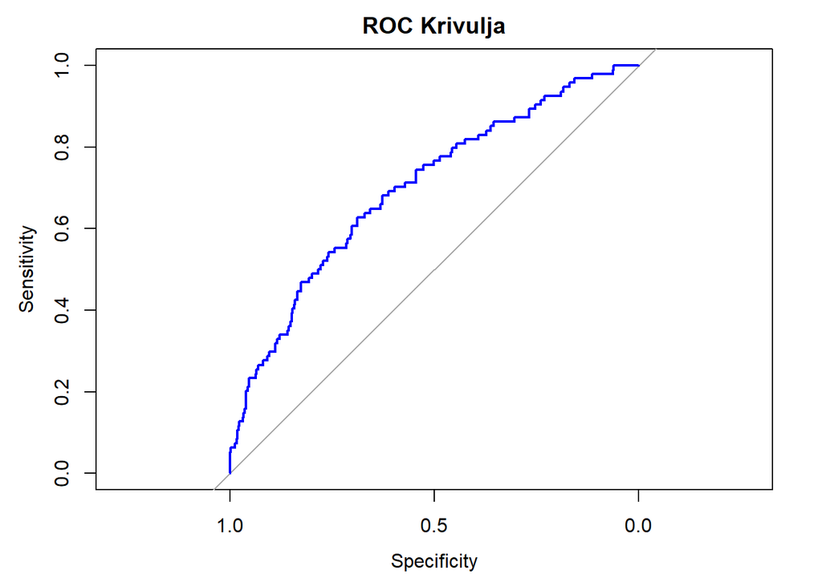

```r
par(family = "sans")
roc_obj <- roc(oscars$IsWinner, predicted_probs)
plot(roc_obj, main = "ROC Krivulja", col = "blue")
```

```r
auc_value <- auc(roc_obj)
print(paste("AUC:", round(auc_value, 4)))
```

```
## [1] "AUC: 0.6991"
```

AUC mjeri sposobnost modela da razlikuje klase. Vrijednost 0.5 predstavlja nasumično pogađanje, a 1.0 predstavlja savršen model. Dobiveni AUC od 0.6991 ukazuje na umjerenu sposobnost modela da razlikuje pobjednike od nominiranih.

#### Evaluacija modela: McFadden’s Pseudo-R^2

```r
null_model <- glm(IsWinner ~ 1, data = oscars, family = binomial)
pseudo_r2 <- 1 - (logLik(model) / logLik(null_model))
print(paste("McFadden's Pseudo-R^2:", round(pseudo_r2, 4)))
```

```
## [1] "McFadden's Pseudo-R^2: 0.0898"
```

Ukazuje na to koliko model bolje objašnjava podatke u usporedbi s nul-modelom. Niska vrijednost (0.0898) sugerira da, iako su varijable statistički značajne, one objašnjavaju samo mali dio varijabilnosti u tome tko će osvojiti Oscara.